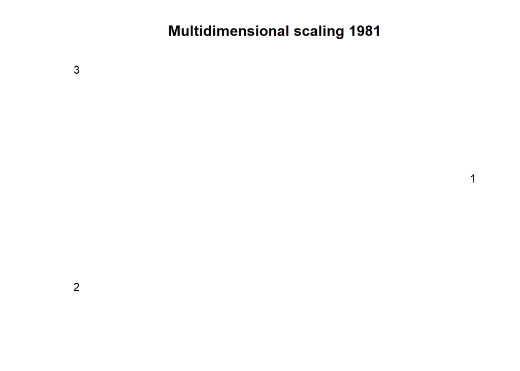

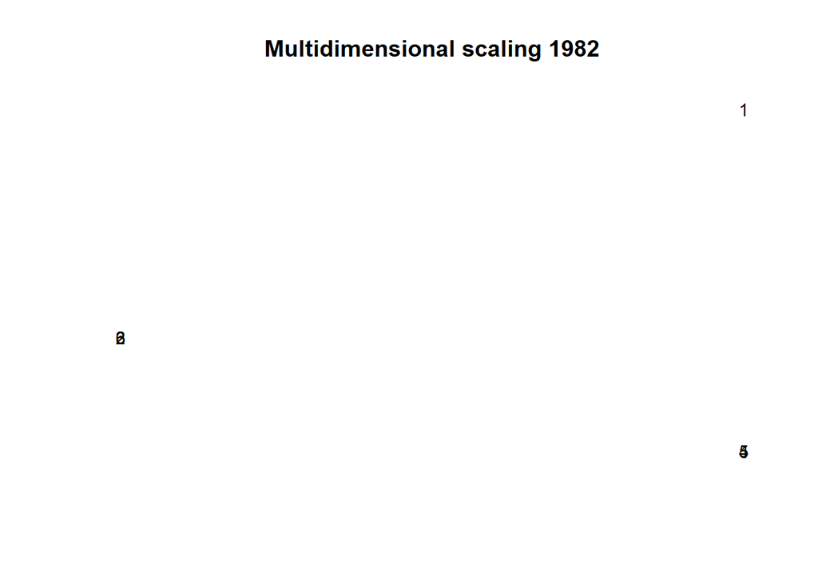

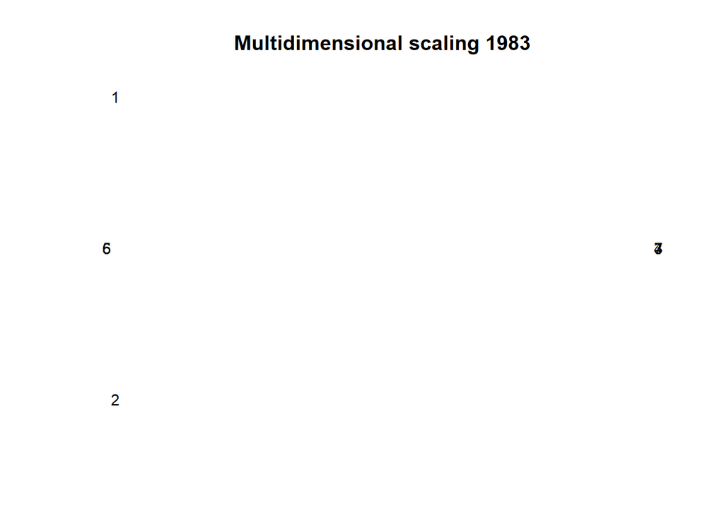

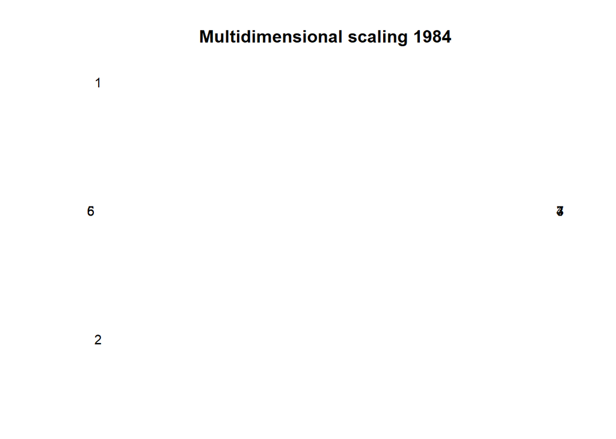

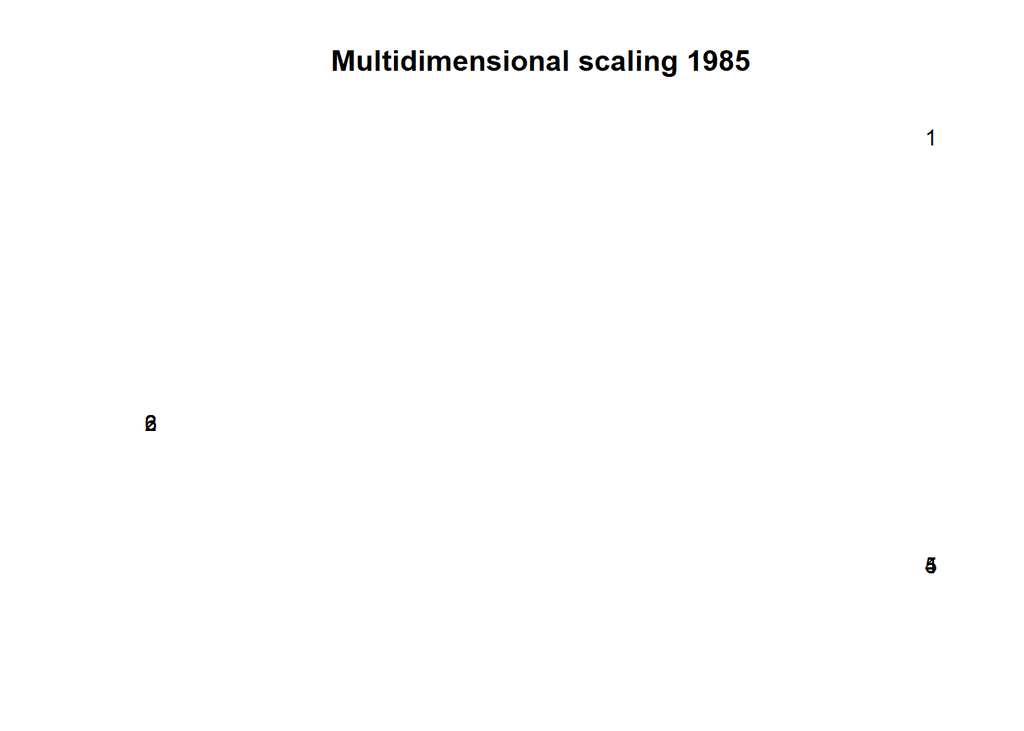

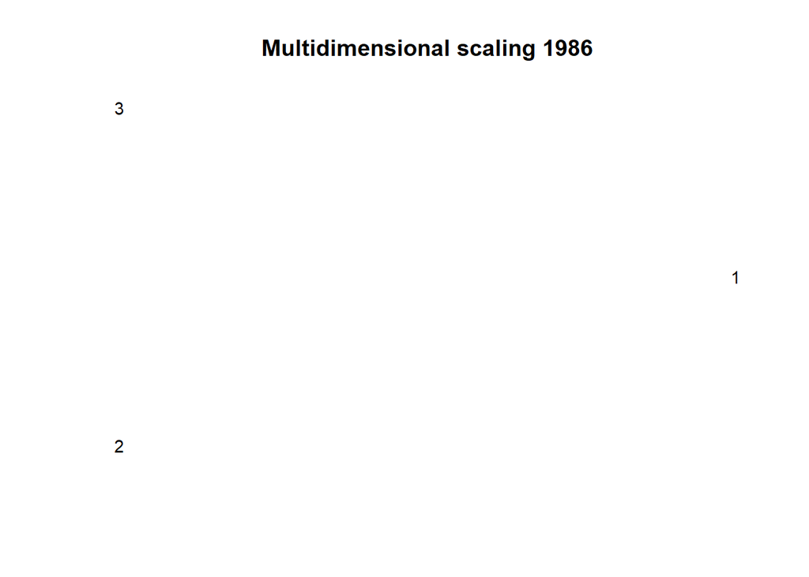

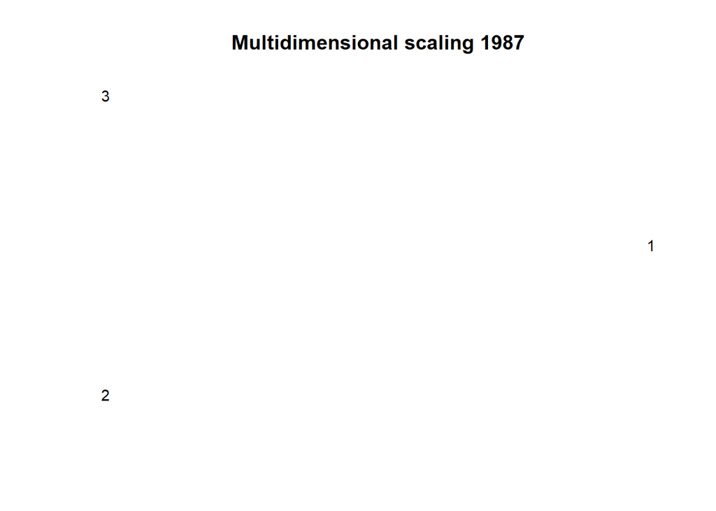

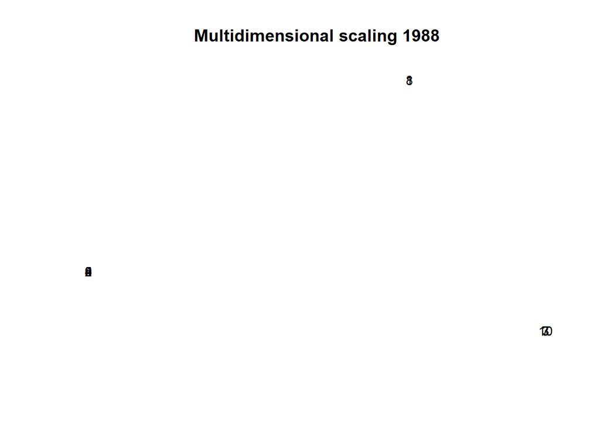

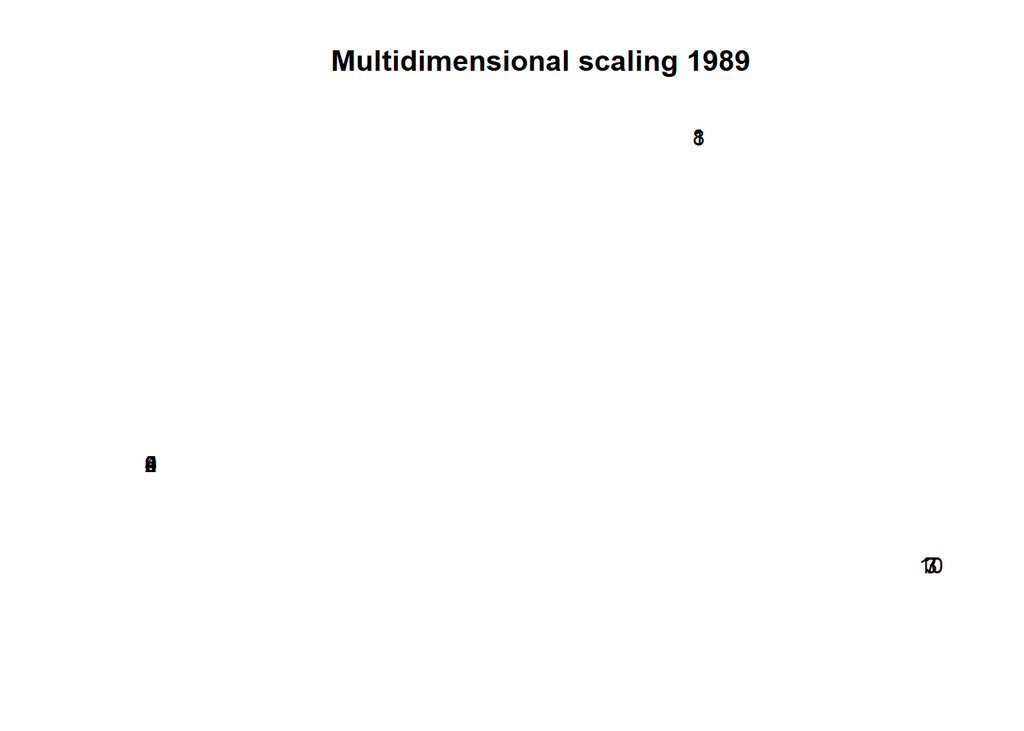

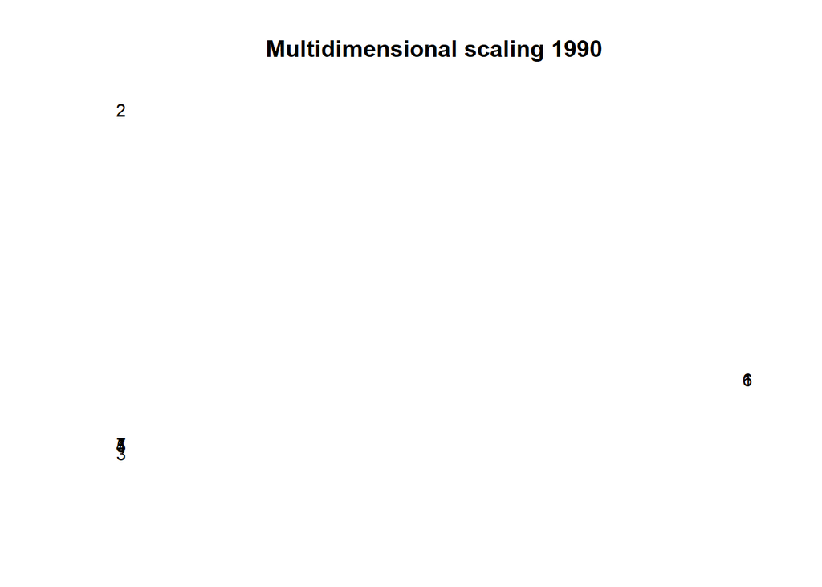

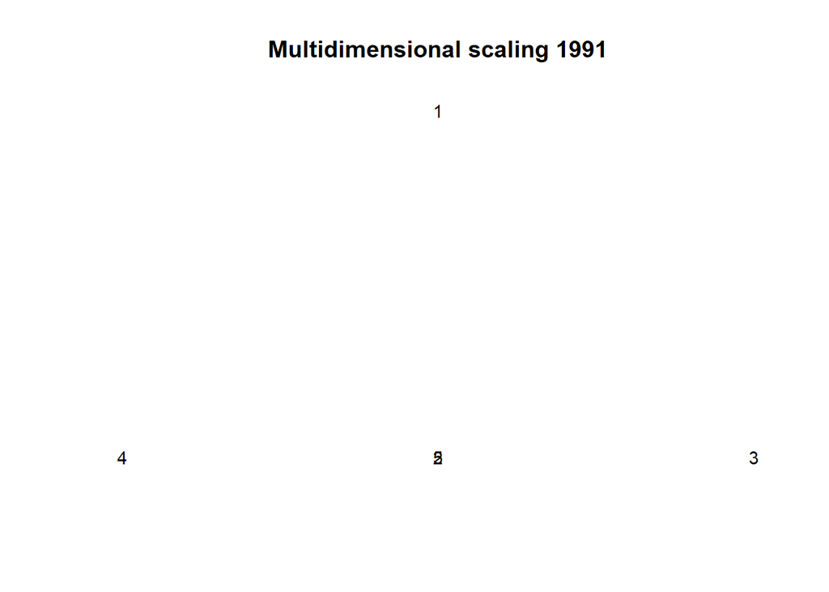

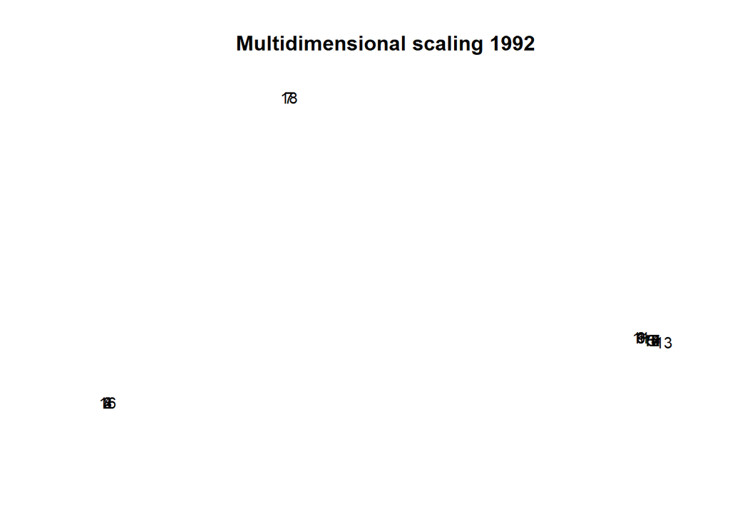

[10 more figures not shown]

[output not shown]

[output cut: 10 more lines]

[output not shown]

```r
#plotting the dimension scaling graphs of first 22 years
lapply(seq_along(dist2), function(i)
  plot(dist2[[i]][,1], dist2[[i]][,2], type = "n", xlab = "", ylab = "", axes = FALSE, main = paste("Multidimensional scaling", 1980+i)) +
  text(dist2[[i]][,1], dist2[[i]][,2], cex = 0.9, xpd = TRUE)
)
```

We could clearly see that the companies were first seprated, then formed small groups. Then some companies within those groups link, which link the groups together and formed a core. Then it formed a core-periphery structure.

```r
#Extra credit: show visually through development of well-defined core in the network to reveal the core-periphery
library(animation)
library(magick)
```

```r
#create a function to potentially generate all the graphs needed by each month
plot_time_series = function(g, m){
  for (i in seq_along(m)){
    layout(matrix(c(1, 2, 1, 3), 2,2, byrow = TRUE), widths=c(3,1), heights=c(1, 1))
    plot(simplify(g[[m[i]]],remove.multiple = TRUE,remove.loops = TRUE),
         vertex.label= "", main = paste("Interaction at month:", m[i]))
  }
}

#create a index/mapper to select the months that we want to display, here I decide to display a month's for every 4 months to reduce the amont of computation needed
map <- seq(from = 2, to = (length(months) - 167), by = 4)

#here I input the function to GIF function, which gonna produce a GIF and save it to local.
#This should produce a simple animation that how a core-periphery forming in this network over time.
saveGIF({
  ani.options(interval = 0.5, convert = shQuote("C:/Program Files/ImageMagick-6.9.9-Q16-HDRI/convert.exe"))
  plot_time_series(g,map)
}, ani.width = 800, ani.height = 500)
```

```
## Output at: animation.gif
```

```
## [1] TRUE
```

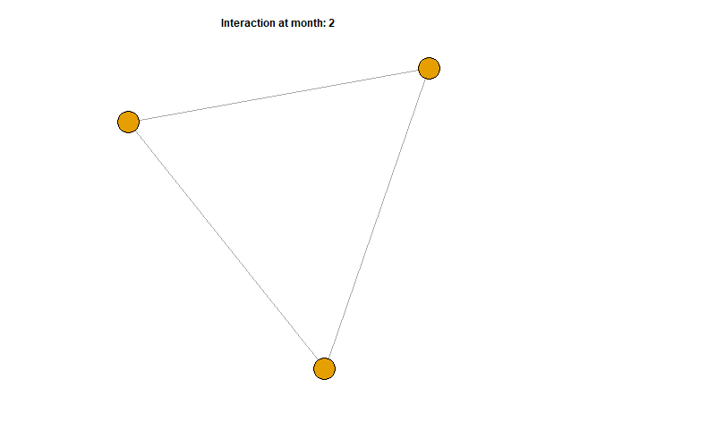

```r
gif <- image_read("C:/Users/10331/OneDrive/Desktop/animation.gif")
gif
```

```r
#Question4
#(A)

#For this question, we calculate degree centrality, closeness centrality, betweenness centrality, eigenvector centrality, and PageRank centrality first, then perform anova analysis to see the significance, direction and strength.

#calculate degree centrality for each month
degree <- lapply(seq_along(g), function(i)
  data.table(investor = V(g[[i]])$name,
             degree = degree(g[[i]], mode = 'all'),
             year = year(months[i])
               ))
degree <- rbindlist(degree,fill=TRUE)
```

```r
#calculate closeness centrality for each month
close2<- lapply(seq_along(g), function(i)
  data.table(investor = V(g[[i]])$name,
             closeness = closeness(g[[i]]),
             year = year(months[i])))
```

[output not shown]

[output cut: 172 more lines]

[output not shown]

[output not shown]

[output cut: 757 more lines]

[output not shown]

```r
close2 <- rbindlist(close2,fill=TRUE)
```

```r
#calculate betweenness centrality for each month
betw <- lapply(seq_along(g), function(i)
  data.table(investor = V(g[[i]])$name,
             betweenness = betweenness(g[[i]]),
             year = year(months[i])))
betw <- rbindlist(betw,fill=TRUE)
```

```r
#calculate page_rank centrality for each month
pr <- lapply(seq_along(g), function(i)
  data.table(investor = V(g[[i]])$name,
             page_rank = page_rank(g[[i]])$vector,
             month = i,
             year = year(months[i])))
pr <- rbindlist(pr,fill=TRUE)
```

```r
#calculate  eigenvector centrality for each month
ec <- lapply(seq_along(g), function(i)
  data.table(investor = V(g[[i]])$name,
             eigen_centrality = eigen_centrality(g[[i]])$vector,
             month = i,
             year = year(months[i])))
ec <- rbindlist(ec,fill=TRUE)
```

```r
#Merge all the centrality scores to one table
dt2 <- degree
dt2$closeness <- close2$closeness
dt2$betweenness <- betw$betweenness
dt2$page_rank <- pr$page_rank
dt2$eigen_centrality <- ec$eigen_centrality

#preview the table
head(dt2)
```

```
##                investor degree year closeness betweenness page_rank
## 1:    Greylock Partners      2 1981       0.5           0 0.3333333
## 2: Sutter Hill Ventures      2 1981       0.5           0 0.3333333
## 3:              Venrock      2 1981       0.5           0 0.3333333
## 4:    Greylock Partners      2 1981       0.5           0 0.3333333
## 5: Sutter Hill Ventures      2 1981       0.5           0 0.3333333
## 6:              Venrock      2 1981       0.5           0 0.3333333
##    eigen_centrality
## 1:                1
## 2:                1
## 3:                1
## 4:                1
## 5:                1
## 6:                1
```

```r
#calculate the last value in the year grouped by company
dt2[,degree := tail(degree,1),by = c("investor","year")]
dt2[,closeness := tail(closeness,1),by = c("investor","year")]
dt2[,betweenness := tail(betweenness,1),by = c("investor","year")]
dt2[,page_rank := tail(page_rank,1),by = c("investor","year")]
dt2[,eigen_centrality := tail(eigen_centrality,1),by = c("investor","year")]
dt2 <- distinct(dt2)

#preview the new table
head(dt2)
```

```
##                investor degree year closeness betweenness page_rank
## 1:    Greylock Partners      2 1981      0.50           0 0.3333333
## 2: Sutter Hill Ventures      2 1981      0.50           0 0.3333333
## 3:              Venrock      2 1981      0.50           0 0.3333333
## 4:    Greylock Partners      2 1982      0.05           0 0.1666667
## 5: Sutter Hill Ventures      2 1982      0.05           0 0.1666667
## 6:              Venrock      2 1982      0.05           0 0.1666667
##    eigen_centrality
## 1:                1
## 2:                1
## 3:                1
## 4:                1
## 5:                1
## 6:                1
```

```r
#Join the data with performance scores
colnames(perform)[1]="investor"
dt2 <- inner_join(dt2, perform, by = c("investor","year"))[,1:9]

#preview the new table
tail(dt2)
```

```
##                        investor degree year    closeness betweenness
## 1:               South Ventures      2 2014 3.204873e-07      0.0000
## 2: Standard Bank Private Equity      4 2014 3.201200e-07      0.0000
## 3:                Space Pirates      3 2014 3.204536e-07      0.0000
## 4:            Dominion Ventures      1 2014 3.202174e-07      0.0000
## 5:                   Vy Capital      7 2014 3.205281e-07    324.8962
## 6:                       Zomato      4 2014 3.206487e-07      0.0000
##       page_rank eigen_centrality successful_investments out_of_business
## 1: 4.475007e-05     2.194552e-04                      0               0
## 2: 5.734021e-05     4.862428e-06                      0               0
## 3: 3.459529e-05     1.610917e-04                      0               0
## 4: 2.605572e-05     5.213885e-05                      0               0
## 5: 6.693913e-05     2.252922e-04                      0               0
## 6: 3.859698e-05     2.566285e-03                      0               0
```

```r
library(pscl)
library(MASS)
#Performance a glm model, as recommended during office hour, on the successful_investment
glm <- glm(data = dt2, formula = successful_investments ~ degree + betweenness + page_rank + closeness + eigen_centrality)

#There are other options for prediction such as hurdle and zero-inflation, however, they produce runtime error on this dataset and won't provide full anova result to analysis, so I didn't apply them here.

#performance anova analysis
summary(glm)
```

```
##
## Call:
## glm(formula = successful_investments ~ degree + betweenness +
##     page_rank + closeness + eigen_centrality, data = dt2)
##
## Deviance Residuals:
##      Min        1Q    Median        3Q       Max
## -12.4991   -0.1914   -0.0246    0.0347   18.9640
##
## Coefficients:
##                    Estimate Std. Error t value Pr(>|t|)
## (Intercept)      -6.500e-02  4.963e-03 -13.096  < 2e-16 ***
## degree            1.490e-02  1.414e-04 105.334  < 2e-16 ***
## betweenness       7.442e-07  1.637e-07   4.546 5.48e-06 ***
## page_rank         8.800e+00  1.743e+00   5.049 4.47e-07 ***
## closeness        -9.307e-01  1.356e+00  -0.687    0.492
## eigen_centrality -2.130e+00  8.185e-02 -26.018  < 2e-16 ***
## ---
## Signif. codes:  0 '***' 0.001 '**' 0.01 '*' 0.05 '.' 0.1 ' ' 1
##
## (Dispersion parameter for gaussian family taken to be 0.7402065)
##
##     Null deviance: 57985  on 37352  degrees of freedom
## Residual deviance: 27644  on 37347  degrees of freedom
## AIC: 94774
##
## Number of Fisher Scoring iterations: 2
```

We can clearly see that four measures are significant in explaining number of successful_investments except closeness. Based on the results, degree/betweenness/page_rank have significant positive relationship with successful_investments. Among the three, page_rank is the most strong positively related indicator based on coefficent. eigen_centrality presents here as a relatively strong negatively related indicator based on coefficent. Degree and betweenness are relatively weaker indicators but still significant.

```r
#(B)
##performance a glm model, as recommended during office hour, on the out_of_business
glm_out <- glm(data = dt2, formula = out_of_business ~ degree + closeness + betweenness + page_rank + eigen_centrality)

#There are other options for prediction such as random forest, however, tree model won't provide full anova result to analysis, so I didn't apply them here.

#performance anova analysis
summary(glm_out)
```

```
##
## Call:
## glm(formula = out_of_business ~ degree + closeness + betweenness +
##     page_rank + eigen_centrality, data = dt2)
##
## Deviance Residuals:
##     Min       1Q   Median       3Q      Max
## -0.2188  -0.1618  -0.1518  -0.1129   1.1395
##
## Coefficients:
##                    Estimate Std. Error t value Pr(>|t|)
## (Intercept)       1.663e-01  1.996e-03  83.316  < 2e-16 ***
## degree           -9.611e-04  5.689e-05 -16.894  < 2e-16 ***
## closeness         1.428e+00  5.452e-01   2.620 0.008809 **
## betweenness       5.229e-07  6.585e-08   7.942 2.05e-15 ***
## page_rank        -2.471e+00  7.011e-01  -3.525 0.000424 ***
## eigen_centrality -2.107e-02  3.292e-02  -0.640 0.522118
## ---
## Signif. codes:  0 '***' 0.001 '**' 0.01 '*' 0.05 '.' 0.1 ' ' 1
##
## (Dispersion parameter for gaussian family taken to be 0.1197469)
##
##     Null deviance: 4563.0  on 37352  degrees of freedom
## Residual deviance: 4472.2  on 37347  degrees of freedom
## AIC: 26734
##
## Number of Fisher Scoring iterations: 2
```

We can clearly see that four measures are significant in explaining number of out_of_business, except eigen_centrality. Based on the results, betweenness/closeness have a positive relationship with out_of_business. Among the two, closeness is the most strong positively related indicator based on coefficent. Page_rank presents here as a strong negatively related indicator based on coefficent. Degree and betweenness are relatively weaker indicators but still significant.

```r
#Question5

#first, get igraphs of each year's july
g5 <- lapply(seq_along(tmp), function(i) g[[tmp[i]]])
```

```r
#use ego graphs to find all the neighborhoods in each months
ego_graph <-lapply(seq_along(g5), function(i) make_ego_graph(g5[[i]], mode = 'all', nodes = V(g5[[i]])))
```

```r
#Create a list for all companies in the for all ego_graph and corresponding months
namelist <- lapply(seq_along(g5), function(i) list(V(g5[[i]])$name))
namelist <- rbindlist(namelist)
monthlist <- lapply(seq_along(g5), function(i) list(rep(tmp[i],length(V(g5[[i]])$name))))
monthlist <- rbindlist(monthlist)
dt3 <- data.table(investor = namelist, month = monthlist)
colnames(dt3)<- c("investor","month")
#find all the corresponding year
dt3[, year:= year(months[month])]
```

```r
#calculate density/constraint/repeated ties/number of firms, and import into a datatable
neigh_measures <- lapply(seq_along(ego_graph),
        function(i) lapply(seq_along(ego_graph[[i]]),
        function(j) data.table(edge_density = edge_density(ego_graph[[i]][[j]], loops=FALSE),
                        avg_constraint = mean(constraint(ego_graph[[i]][[j]], weights=NULL)),
                        average_repeated_ties = mean(E(ego_graph[[i]][[j]])$repeated),
                        number_of_firms = length(V(ego_graph[[i]][[j]])$name),
                        avg_age = mean(E(ego_graph[[i]][[j]])$tie_age)
        )
))

#collapse the huge datatable into a long table
neigh_measures <- lapply(seq_along(neigh_measures), function(i) rbindlist(neigh_measures[[i]]))
neigh_measures2 = data.table()
for (i in seq_along(neigh_measures)){
 neigh_measures2 = rbind(neigh_measures2, neigh_measures[[i]])
}

#combine the name table and the measure table
dt4 <- cbind(dt3, neigh_measures2)

#innerjoin with performance
dt4 <- inner_join(dt4, perform, by = c("investor","year"))[,1:10]

#innerjoin with average cumulative success
dt4 <- inner_join(dt4, perform2, by = c("investor","year"))
```

```r
#Performance a glm model, as recommended during office hour, on the successful_investment
glm <- glm(data = dt4, formula = successful_investments ~ edge_density + avg_constraint + average_repeated_ties + number_of_firms + avg_age + cumulative)

#performance anova analysis
summary(glm)
```

```
##
## Call:
## glm(formula = successful_investments ~ edge_density + avg_constraint +
##     average_repeated_ties + number_of_firms + avg_age + cumulative,
##     data = dt4)
##
## Deviance Residuals:
##      Min        1Q    Median        3Q       Max
## -16.2904   -0.1285   -0.0602   -0.0150   14.9524
##
## Coefficients:
##                         Estimate Std. Error t value Pr(>|t|)
## (Intercept)            1.233e-01  2.044e-02   6.031 1.65e-09 ***
## edge_density           1.022e-01  6.603e-03  15.472  < 2e-16 ***
## avg_constraint        -1.724e-01  2.131e-02  -8.088 6.30e-16 ***
## average_repeated_ties -6.391e-03  1.923e-03  -3.323 0.000891 ***
## number_of_firms        2.186e-03  2.258e-04   9.681  < 2e-16 ***
## avg_age               -1.549e-04  2.137e-05  -7.248 4.34e-13 ***
## cumulative             2.024e-01  1.189e-03 170.271  < 2e-16 ***
## ---
## Signif. codes:  0 '***' 0.001 '**' 0.01 '*' 0.05 '.' 0.1 ' ' 1
##
## (Dispersion parameter for gaussian family taken to be 0.5972303)
##
##     Null deviance: 57131  on 32232  degrees of freedom
## Residual deviance: 19246  on 32226  degrees of freedom
## AIC: 74868
##
## Number of Fisher Scoring iterations: 2
```

We can clearly see that all six measures are significant in explaining number of successful_investments. Based on the results, edge_density/cumulative//number_of_firms have significant positive relationship with successful_investments. Among the three, cumulative success is the most strong positively related indicator based on coefficent, followed by edge_density. avg_constraint presents here as a strong negatively correlated indicator based on coefficent. average_repeated_ties/number_of_firms/avg_age are relatively weaker indicators but still significant.

```r
##performance a glm model, as recommended during office hour, on the out_of_business
glm_out <- glm(data = dt4, formula = out_of_business ~ edge_density + avg_constraint + average_repeated_ties + number_of_firms + avg_age + cumulative)

#performance anova analysis
summary(glm_out)
```

```
##
## Call:
## glm(formula = out_of_business ~ edge_density + avg_constraint +
##     average_repeated_ties + number_of_firms + avg_age + cumulative,
##     data = dt4)
##
## Deviance Residuals:
##      Min        1Q    Median        3Q       Max
## -0.76631  -0.16589  -0.09497  -0.02713   1.05526
##
## Coefficients:
##                         Estimate Std. Error t value Pr(>|t|)
## (Intercept)            1.024e-01  8.321e-03  12.312  < 2e-16 ***
## edge_density           4.311e-02  2.688e-03  16.041  < 2e-16 ***
## avg_constraint         9.078e-02  8.675e-03  10.465  < 2e-16 ***
## average_repeated_ties -1.253e-02  7.828e-04 -16.011  < 2e-16 ***
## number_of_firms       -3.657e-04  9.191e-05  -3.979 6.94e-05 ***
## avg_age               -1.325e-04  8.700e-06 -15.235  < 2e-16 ***
## cumulative             9.541e-04  4.839e-04   1.972   0.0486 *
## ---
## Signif. codes:  0 '***' 0.001 '**' 0.01 '*' 0.05 '.' 0.1 ' ' 1
##
## (Dispersion parameter for gaussian family taken to be 0.09894712)
##
##     Null deviance: 3395.5  on 32232  degrees of freedom
## Residual deviance: 3188.7  on 32226  degrees of freedom
## AIC: 16922
##
## Number of Fisher Scoring iterations: 2
```

We can clearly see that all six measures are significant in explaining number of out_of_business. Based on the results, edge_density/avg_constraint/cumulative have a positive relationship with out_of_business. Among the three, avg_constraint is the relatively strong positively related indicator based on coefficent, followed by edge_density. average_repeated_ties here as a relatively strong negatively related indicator based on coefficent. cumulative/number_of_firms/avg_age presents are relatively weaker indicators but still significant.